# How to process an NMR dataset with speaq2

Charlie Beirnaert

2017-03-23

## speaq2

To illustrate the possibilities of **speaq2**, the spiritual successor to the original speaq package, we will analyse the onion intake in mice dataset (available form the University of Copenhagen at ). This is the same dataset as analysed in the paper and was originally analysed by Winning et al. (DOI: 10.1039/B918259D)

Before we start with the example let’s first recap what the basic steps of speaq2 encompass:

1. Peak detection: `getWaveletPeaks()`
2. Peak alignment: `PeakAligner()`
3. Peak filling: `PeakFilling()`
4. Feature matrix construction: `BuildFeatureMatrix()`

These functions alongside other functionality from speaq2 will be demonstrated in this vignette. Note that there is a plotting function available in speaq2 (for raw spectra) but the features are naturally plotted with ggplot2. The code for these plots are also included in this vignette, although thet might seem rather elaborate, they are pretty straightforward and might provide inspiration for your own plots.

### Loading the necessary dataset

Adjust the location of the dataset if necessary

```r
library(speaq2)
load("Oniondata.rda")
Spectra <- Oniondata$spectra
ppm.onion <- Oniondata$ppm
onion.percent <- Oniondata$onion.percent
onion.grouplabels <- Oniondata$grouplabels
```

```
## There might be a gap in the data, the minimal and maximal differences between consecutive ppm points are respectively 0.000305499999999626 and 0.4284074
```

```
## Warning in drawSpecPPM(Y.spec = Spectra, X.ppm = ppm.onion, groupFactor =
## onion.grouplabels, : groupFactor is not a factor, attempting conversion.
```

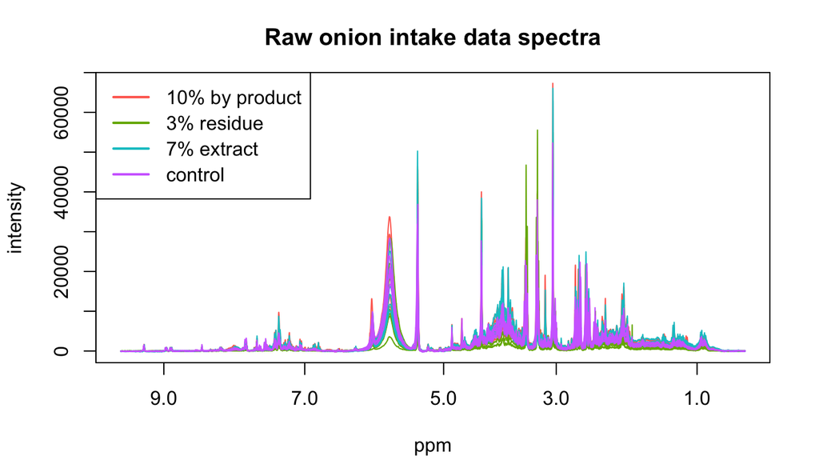

```r
# plot of all spectra
drawSpecPPM(Y.spec = Spectra,
            X.ppm = ppm.onion,
            groupFactor = onion.grouplabels,
            title = 'Raw onion intake data spectra',
            legend.extra.x = 1,
            legend.extra.y = 1.1)
```

The `drawSpecPPM()` plotting function indicates that there might be a gap in the data (which is correct as the original authors deleted the region between 5.0 and 4.5 ppm). This warning can be of importance for the interpretation of the plot as in this case the original authors deleted the data, not by setting the values to 0, but by effectively removing it from the matrix and ppm vector. This produces a plot that appears continuous but is in fact not.

The `drawSpecPPM()` function also indicates that the groupFactor is not a factor and (succesfully) attempts to do the conversion. The next plot is an excerpt of the onion intake dataset.

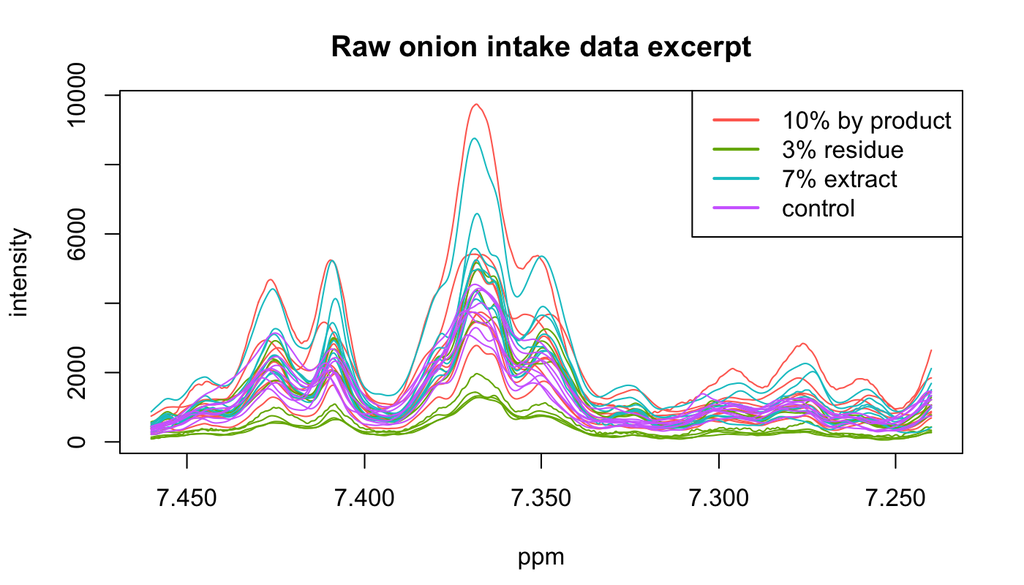

```r
# small excerpt by defining the region of interest
drawSpecPPM(Y.spec = Spectra,
            X.ppm = ppm.onion,
            groupFactor = as.factor(onion.grouplabels),
            title = 'Raw onion intake data excerpt',
            legend.extra.x = 1.1,
            legend.extra.y = 1.0,
            ROI.ppm = 7.35,
            ROI = NULL,
            roiWidth.ppm = 0.11,
            legendpos = "topright" )
```

### From spectra via peaks to aligned peaks (features)

Now that we’ve had a look at the spectra it is time to convert these to peaks by using the `getWaveletPeaks()` function. Since this can take some time (2 minutes, with `nCPU = 6`, on a 2.5GHz machine).

```r
onion.peaks <- getWaveletPeaks(Y.spec = Spectra,
                              X.ppm = ppm.onion,
                              baselineThresh = 10,
                              SNR.Th = -1,
                              nCPU = 2,
                              include_nearbyPeaks = TRUE)
```

The next step in speaq2 is the alignment.

```r
onion.aligned <- PeakAligner(Y.peaks = onion.peaks,
                             min.samp.grp = 5)
```

Now we can plot the detected peaks and the aligned peaks with the `onion.aligned` object. The dataset after alignment contains both the original ppm values of every peak (in the `peakPPM` variable) but also the group information (found in the `peakIndex` variable). By calling the `AddPlottingStuff()` function the groupPPM variable is added so we also have the ppm value of the groups (the link is: `groupPPM <- ppm.onion[peakIndex]`)

### Plotting the peak data

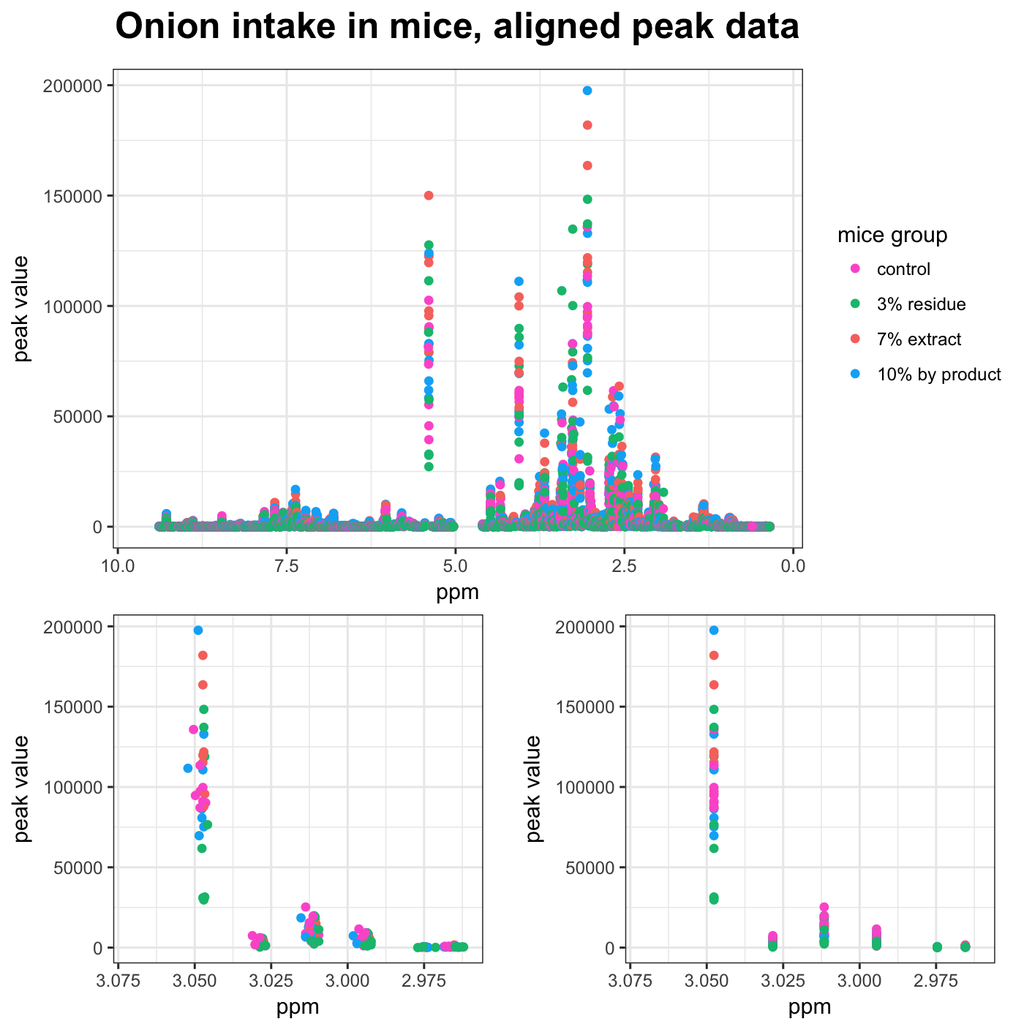

```r
# adding labels to the dat a for plotting and the group ppm values
library(gridExtra)
library(ggplot2)

onion.peaks.plot <- AddPlottingStuff(Y.peaks = onion.peaks,
                                    X.ppm = ppm.onion,
                                    groupLabels = onion.grouplabels )
onion.peaks.plot$label <- factor(onion.peaks.plot$label, levels = c("control",
                                                                    "3% residue",
                                                                    "7% extract",
                                                                    "10% by product"))

onion.aligned.plot <- AddPlottingStuff(Y.peaks = onion.aligned,
                                       X.ppm = ppm.onion,
                                       groupLabels = onion.grouplabels )
onion.aligned.plot$label <- factor(onion.aligned.plot$label,  levels = c("control",
                                                                         "3% residue",
                                                                         "7% extract",
                                                                         "10% by product"))
# region for the zoom in plots
mi = 20000
ma = 20360

# the plotting
plot.legend <- ggplot(onion.aligned.plot, aes(x=peakPPM, y=peakValue, colour = label) ) +
               geom_point() +
               theme_bw() +
               xlim(c(as.numeric(max(ppm.onion)),as.numeric(min(ppm.onion)))) +
               theme(legend.key = element_blank(),
                     plot.margin = unit(c(0,2,0,0.1), "cm"))+
               scale_colour_manual( values = c("control" = "#FD61D1",
                                               "3% residue" = "#00BF7D",
                                               "7% extract" = "#F8766D",
                                               "10% by product" = "#00B0F6")) +
               labs(x = "ppm", y = "peak value")



pp1 <- ggplot(onion.aligned.plot, aes(x=peakPPM, y=peakValue, colour = label) ) +
       geom_point() +
       theme_bw() +
       xlim(c(as.numeric(max(ppm.onion)),as.numeric(min(ppm.onion)))) +
       theme(legend.key = element_blank(),
             plot.title = element_text(lineheight = 0.8,
                                               face = "bold",
                                               margin = margin(0,0,13,0),
                                               hjust = 0.5,
                                               size = 18)) +
       ggtitle("Onion intake in mice, aligned peak data") +
       scale_colour_manual(name = "mice group", values = c("control" = "#FD61D1",
                                                           "3% residue" = "#00BF7D",
                                                           "7% extract" = "#F8766D",
                                                           "10% by product" = "#00B0F6")) +
       labs(x = "ppm", y = "peak value")


pp2 <- ggplot(onion.aligned.plot[onion.aligned.plot$peakIndex > mi &
                                 onion.aligned.plot$peakIndex < ma ,],
              aes(x=peakPPM, y=peakValue, colour = label) ) +
       geom_point() +
       theme_bw() +
       xlim(c(as.numeric(ppm.onion[mi]),as.numeric(ppm.onion[ma]))) +
       guides(color=FALSE) +
       theme(plot.margin = unit(c(0,0.5,0.1,0.2), "cm")) +
       scale_colour_manual(values = c("control" = "#FD61D1",
                                      "3% residue" = "#00BF7D",
                                      "7% extract" = "#F8766D",
                                      "10% by product" = "#00B0F6")) +
       labs(x = "ppm", y = "peak value")


pp3 <- ggplot(onion.aligned.plot[onion.aligned.plot$peakIndex > mi &
                                 onion.aligned.plot$peakIndex < ma ,],
              aes(x=groupPPM, y=peakValue, colour = label) ) +
       geom_point() +
       theme_bw() +
       xlim(c(as.numeric(ppm.onion[mi]),as.numeric(ppm.onion[ma]))) +  guides(color=FALSE) +
       theme(plot.margin = unit(c(0,0.5,0.1,0.2), "cm")) +
       scale_colour_manual(values = c("control" = "#FD61D1",
                                      "3% residue" = "#00BF7D",
                                      "7% extract" = "#F8766D",
                                      "10% by product" = "#00B0F6")) +
       labs(x = "ppm", y = "peak value")



g_legend <- function(a.gplot){
    tmp <- ggplot_gtable(ggplot_build(a.gplot))
    leg <- which(sapply(tmp$grobs, function(x) x$name) == "guide-box")
    legend <- tmp$grobs[[leg]]
    return(legend)
    }

legend <- g_legend(plot.legend)

lay <- rbind(c(1,1,1,1),
             c(1,1,1,1),
             c(1,1,1,1),
             c(2,2,3,3),
             c(2,2,3,3))

grid.arrange(pp1, pp2, pp3, layout_matrix = lay)
```

In the top plot you can clearly see the portion of the data that has been deleted by the original authors, in the bottom plots the difference between pre-alignment (left) and post-alignment (right) is clearly visible. With the aligned peaks, which are now regarded as features, we can identify those features that are of interest. Before that however, it is a good idea to check the quality of the grouping by means of a silhouette plot.

```r
SilhouetteValues <- SilhouetR(DataMatrix = onion.aligned$peakPPM,
                              GroupIndices = onion.aligned$peakIndex)
```

```
## DataMatrix is not a matrix, attempting conversion with the assumption of only 1 variable (1 column)
```

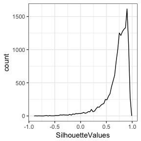

```r
Silh_plot <- ggplot(SilhouetteValues, aes(SilhouetteValues)) +
             geom_freqpoly(binwidth = 0.03) +
             theme_bw()
Silh_plot
```

The grouping is clearly of good quality. To verify the grouping in more detail let’s calculate the average Silhouette values per group and see if there are anny groups which have a low average silhouette value.

```r
groups <- unique(SilhouetteValues$GroupIndices)
Ngroups <- length(groups)
sil_means <- matrix(NA, ncol = 3, nrow = Ngroups)

for(k in 1:Ngroups){
    sil_means[k,1] = groups[k]
    sil_means[k,2] = mean(SilhouetteValues$SilhouetteValues[SilhouetteValues$GroupIndices==groups[k]])
    sil_means[k,3] = mean(onion.aligned$peakSNR[onion.aligned$peakIndex==groups[k]])
}

sil_means <- sil_means[order(sil_means[,2]),]
colnames(sil_means) <- c("groupIndex", "avg_silhouette_val", "avg. SNR")
head(sil_means)
```

```
##      groupIndex avg_silhouette_val  avg. SNR
## [1,]      24640        -0.42902682  2.630767
## [2,]       1466        -0.22826950  3.108449
## [3,]      17006        -0.06651496  3.880920
## [4,]      20866         0.07141069  3.351991
## [5,]      21310         0.24089172 53.866538
## [6,]       3078         0.27043075 11.781341
```

Cleary there are some groups with a very low average silhouette value, these groups are however of low signal to noise ratio and therefor are probably peaks detected in the very low intensity or noisy signals (plot them to see this is in fact the case). LAter when constructing the feature matrix we have to option to eliminate these groups.

There is one group which has a high SNR value but a relatively low average silhouette value. Let’s plot this group:

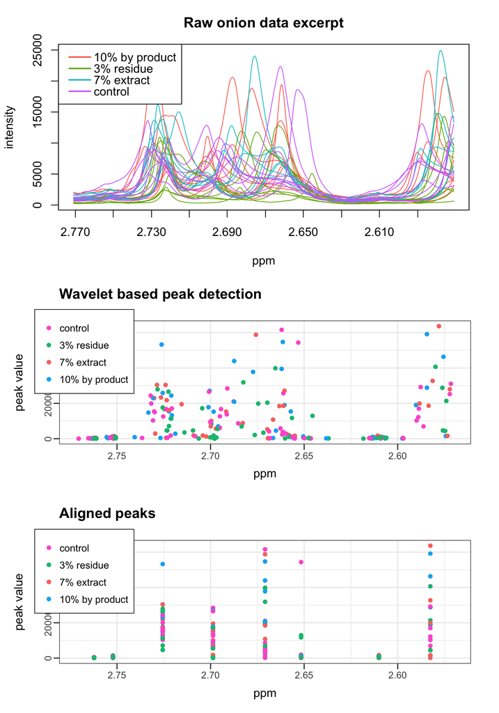

```r
library(grid)
library(gridBase)
library(gridExtra)
library(ggplot2)

faulty.groupIndex <- sil_means[5,1]
ROI.ppm <- ppm.onion[faulty.groupIndex]
roiWidth.ppm <- 0.1
pp1 <- ggplot(onion.peaks.plot[onion.peaks.plot$peakPPM > (ROI.ppm - roiWidth.ppm ) &
                              onion.peaks.plot$peakPPM < (ROI.ppm + roiWidth.ppm ) ,],
              aes(x = peakPPM, y = peakValue, colour = label) ) +
       geom_point() +
       xlim(c(ROI.ppm + roiWidth.ppm, ROI.ppm - roiWidth.ppm)) +
       scale_colour_manual(values = c("control" = "#FD61D1",
                                      "3% residue" = "#00BF7D",
                                      "7% extract" = "#F8766D",
                                      "10% by product" = "#00B0F6")) +
       labs(x = "ppm", y = "peak value") +
       ggtitle("Wavelet based peak detection") +
       theme_bw() +
       theme(legend.title = element_blank(),
             legend.position = c(0.061,0.75),
             legend.background = element_rect(colour = "black", size = 0.3, linetype = 1),
             legend.key = element_blank(),
             legend.text = element_text(size=10),
             text = element_text(size = 12),
             axis.text.y = element_text(angle=90, hjust=0.5),
             axis.ticks.length = unit(0.2,"cm"),
             axis.title.x = element_text(margin=margin(10,0,0,0)),
             axis.title.y = element_text(margin=margin(0,20,0,0)),
             plot.title = element_text(lineheight = 0.8, face = "bold", margin = margin(0,0,20,0)),
             plot.margin = unit(c(0.5,1,0.5,0.5), "cm"))


pp2 <- ggplot(onion.aligned.plot[onion.aligned.plot$groupPPM > (ROI.ppm - roiWidth.ppm ) &
                                onion.aligned.plot$groupPPM < (ROI.ppm + roiWidth.ppm ) ,],
              aes(x = groupPPM, y = peakValue, colour = label) ) +
       geom_point() +
       theme_bw() +
       xlim(c( ROI.ppm + roiWidth.ppm, ROI.ppm - roiWidth.ppm)) +
       scale_colour_manual(values = c("control" = "#FD61D1",
                                      "3% residue" = "#00BF7D",
                                      "7% extract" = "#F8766D",
                                      "10% by product" = "#00B0F6")) +
       labs(x = "ppm", y = "peak value") +
       ggtitle("Aligned peaks") +
       theme(legend.title = element_blank(),
             legend.position = c(0.061,0.748),
             legend.background = element_rect(colour = "black", size = 0.3, linetype = 1),
             legend.key = element_blank(),
             legend.text = element_text(size = 10),
             text = element_text(size = 12),
             axis.text.y = element_text(angle = 90, hjust = 0.5),
             axis.ticks.length = unit(0.2,"cm"),
             axis.title.x = element_text(margin = margin(10,0,0,0)),
             axis.title.y = element_text(margin = margin(0,20,0,0)),
             plot.title = element_text(lineheight = 0.8, face="bold", margin = margin(0,0,20,0)),
             plot.margin = unit(c(0.5,1,0.5,0.5), "cm"))

plot.new()


grid.newpage()
pushViewport(viewport(layout = grid.layout(13, 1)))

#Draw ggplot1
pushViewport(viewport(layout.pos.row = (6:9)))
print(pp1, newpage = FALSE)
popViewport()

#Draw ggplot2
pushViewport(viewport(layout.pos.row = (10:13)))
print(pp2, newpage = FALSE)
popViewport()

#Draw bsae plot
pushViewport(viewport(layout.pos.row = (1:5)))
par(fig = gridFIG(), new = TRUE)
drawSpecPPM(Y.spec = Spectra,
            X.ppm = ppm.onion,
            groupFactor = as.factor(onion.grouplabels),
            title = "Raw onion data excerpt",
            ROI.ppm = ROI.ppm,
            roiWidth.ppm = roiWidth.ppm,
            nAxisPos = 6,
            legend.extra.x = 0.3,
            legend.extra.y = 0.8)
popViewport()
```

This group is clearly quite a mess but the grouping seems to be of ok quality so we’ll leave it at that.

```r
onion.filled <- PeakFilling(Y.aligned = onion.aligned,
                            Y.spec = Spectra,
                            max.index.shift = 10,
                            nCPU = 2) # nCPU set to 1 for the vignette build


onion.Features <- BuildFeatureMatrix(onion.filled)
```

### Intermezzo: PCA

Now that we have the feature matrix we can quickly perform a PCA (principal component analysis) as a way of visualising potential trends and groups in the data. Before any PCA it is advised to scale and center the data, here we will use the pareto scaling but other are available (see the `SCANT()` helpfile)

```r
onion.Features.scaled <- SCANT(onion.Features, type = c("pareto", "center"))
```

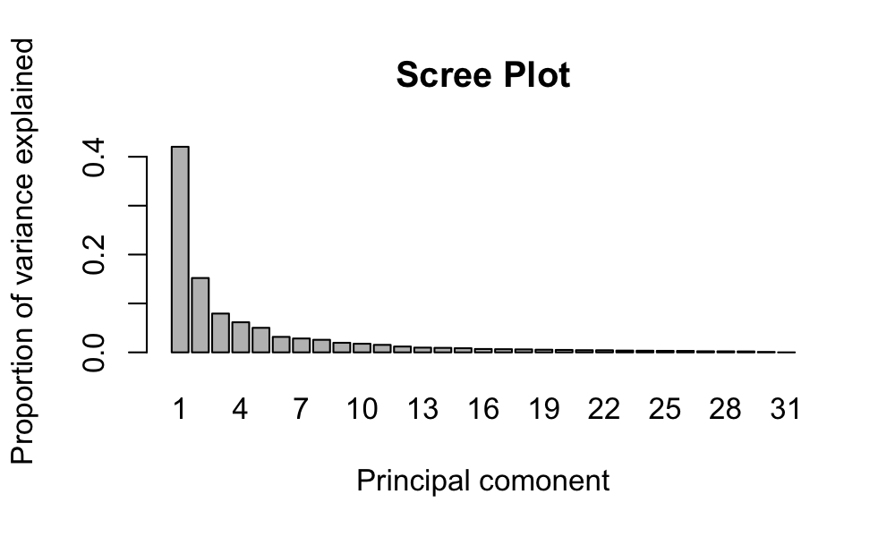

```r
library(stats)

common.pca <- prcomp(onion.Features.scaled)


loadings <- common.pca$rotation
scores <- common.pca$x
varExplained <- common.pca$sdev^2

barplot(varExplained/sum(varExplained),
        main="Scree Plot",
        ylab="Proportion of variance explained",
        xlab = "Principal comonent",
        names.arg = as.character(seq(1,length(varExplained))) )
```

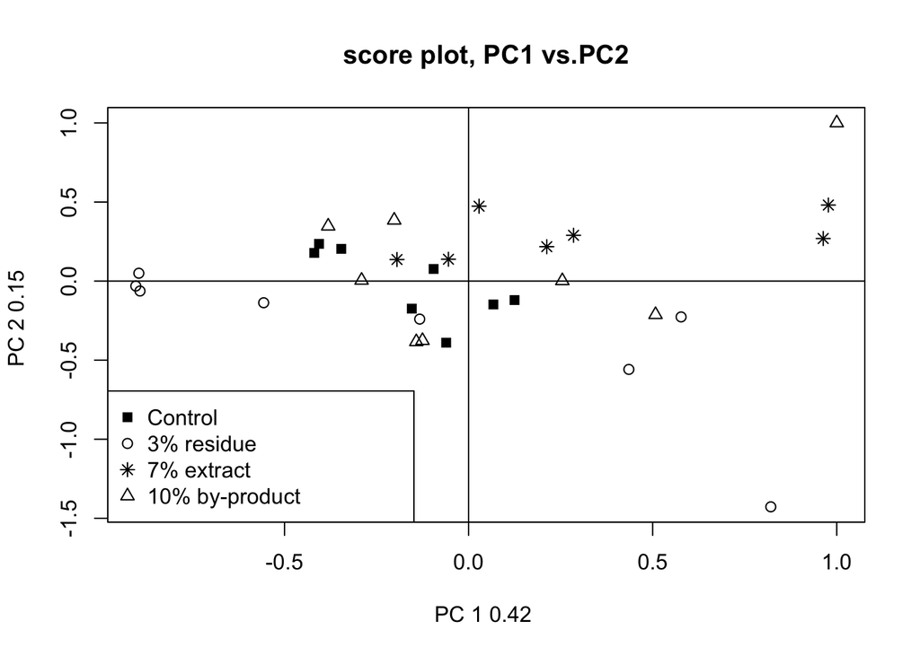

```r
plot.marks <- as.numeric(onion.percent)
plot.marks[plot.marks == 0] <- 15
plot.marks[plot.marks == 3] <- 1
plot.marks[plot.marks == 7] <- 8
plot.marks[plot.marks == 10] <- 2

cp1 <- 1
cp2 <- 2
plot(scores[,cp1]/max(scores[,cp1]), scores[,cp2]/max(scores[,cp2]),
     main=paste("score plot, PC",cp1," vs.PC",cp2,sep=""),
     xlab=paste("PC",cp1,round(varExplained[cp1]/sum(varExplained),digits=2),""),
     ylab=paste("PC",cp2,round(varExplained[cp2]/sum(varExplained),digits=2),""),
     pch = plot.marks)
lines(x = c(-100,100), y = c(0,0))
lines(x = c(0,0), y = c(-100,100))
legend("bottomleft",
       legend = c("Control ","3% residue ",
                  "7% extract    ", "10% by-product                 "),
       pch = c(15,1,8,2),
       y.intersp = 1)
```

There is little to nothing to be found in the PCA analysis, this is also what [Winning et al.](http://pubs.rsc.org/en/Content/ArticleLanding/2009/AN/b918259d#!divAbstract) concluded in there paper (DOI: 10.1039/B918259D).

### A differential analysis based on linear models

Next we can use the `relevant.features()` function in speaq2 which uses linear models to produce a p-value corresponding to the nulhypothesis that feature x is not related to the outcome vector. After a p-value correction for multiple testing (as with increasing numbers of randomly generated features some will eventually be significantly related to the output vector) we can identify the relevant features.

```r
p.all_bonf <- relevant.features.p(onion.Features.scaled , onion.percent, p.adj = "bonferroni")




significant.features <- p.all_bonf[p.all_bonf$p.values<=0.05, ]

# order from most significant
significant.features <- significant.features[order(significant.features[,2]),]
head(significant.features)
```

```
##     index     p.values
## 233  9181 7.009079e-07
## 471 19723 5.566127e-06
## 454 18662 7.330029e-04
## 229  9014 3.251326e-03
## 234  9234 4.673004e-03
## 472 19752 5.051756e-03
```

It is clear that some features are well below the commonly used 0.05 p-value threshold. We can now easily find which features correspond to the low p-values and consequently plot them.

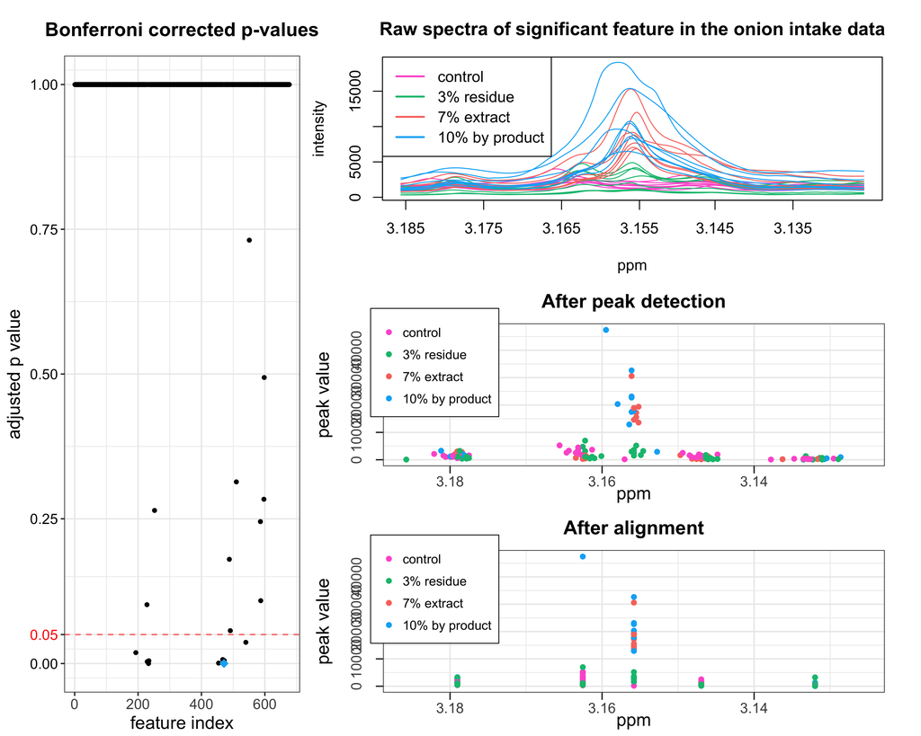

```r
.pardefault <- par(no.readonly = T)

p.all_bonf <- relevant.features.p(onion.Features.scaled , onion.percent, p.adj = "bonferroni")




significant.features <- p.all_bonf[p.all_bonf$p.values<=0.05, ]
significant.features <- significant.features[order(significant.features[,2]),]
peak_of_interest <- 2# change this number to any of the peaks you want to see
faulty.groupIndex <- significant.features$index[peak_of_interest]
faulty.peakIndex <- as.numeric(rownames(significant.features))[peak_of_interest]

#ROI.ppm <- 3.6
#roiWidth.ppm <- 0.15
ROI.ppm <- ppm.onion[faulty.groupIndex]
roiWidth.ppm <- 0.03

pp1 <- ggplot(onion.peaks.plot[onion.peaks.plot$peakPPM > (ROI.ppm - 2*roiWidth.ppm ) &
                              onion.peaks.plot$peakPPM < (ROI.ppm + 2*roiWidth.ppm ) ,],
              aes(x = peakPPM, y = peakValue, colour = label) ) +
       geom_point() +
       theme_bw() +
       xlim(c(ROI.ppm + roiWidth.ppm, ROI.ppm - roiWidth.ppm)) +
       scale_colour_manual(values = c("control" = "#FD61D1",
                                      "3% residue" = "#00BF7D",
                                      "7% extract" = "#F8766D",
                                      "10% by product" = "#00B0F6")) +
       labs(x = "ppm", y = "peak value") +
       ggtitle("After peak detection") +
       theme(legend.title = element_blank(),
             legend.position = c(0.103,0.726),
             legend.background = element_rect(colour = "black", size = 0.3, linetype = 1),
             legend.key = element_blank(),
             legend.text = element_text(size = 10),
             text = element_text(size = 14),
             axis.text.y = element_text(angle = 90, hjust = 0.5, margin = margin(0,0.4,0,0,"cm")),
             axis.ticks.length = unit(0.2,"cm"),
             axis.title.x = element_text(margin = margin(0,0,0,0)),
             axis.title.y = element_text(margin = margin(0,15,0,0)),
             plot.title = element_text(lineheight = 0.8, face="bold", margin = margin(0,0,10,0),hjust = 0.5, size = 15),
             plot.margin = unit(c(0.3,1,0.2,0.25), "cm"))



pp2 <- ggplot(onion.aligned.plot[onion.aligned.plot$peakPPM > (ROI.ppm - 2*roiWidth.ppm ) &
                                onion.aligned.plot$peakPPM < (ROI.ppm + 2*roiWidth.ppm ) ,],
               aes(x = groupPPM, y = peakValue, colour = label) ) +
       geom_point() +
       theme_bw() +
       xlim(c(ROI.ppm + roiWidth.ppm, ROI.ppm - roiWidth.ppm)) +
       scale_colour_manual(values = c("control" = "#FD61D1",
                                      "3% residue" = "#00BF7D",
                                      "7% extract" = "#F8766D",
                                      "10% by product" = "#00B0F6")) +
       labs(x = "ppm", y = "peak value") +
       ggtitle("After alignment") +
       theme(legend.title = element_blank(),
             legend.position = c(0.103,0.726),
             legend.background = element_rect(colour = "black",size = 0.3, linetype = 1),
             legend.key = element_blank(),
             legend.text = element_text(size = 10),
             text = element_text(size = 14),
             axis.text.y = element_text(angle = 90, hjust = 0.5, margin = margin(0,0.4,0,0,"cm")),
             axis.ticks.length = unit(0.2,"cm"),
             axis.title.x = element_text(margin = margin(0,0,0,0)),
             axis.title.y = element_text(margin = margin(0,15,0,0)),
             plot.title = element_text(lineheight = 0.8, face="bold", margin = margin(0,0,10,0),hjust = 0.5, size = 15),
             plot.margin = unit(c(0.3,1,0.2,0.25), "cm"))

pp3 = ggplot(p.all_bonf, aes(x=as.numeric(rownames(p.all_bonf)), y=p.values)) +
         geom_point(data = p.all_bonf[-faulty.peakIndex,],
                    aes(x=as.numeric(rownames(p.all_bonf[-faulty.peakIndex,])),
                        y =p.values),
                    shape = 16) +
    geom_point(data = p.all_bonf[faulty.peakIndex,],
               aes(x=faulty.peakIndex, y =p.values),
               shape = 18,
               size = 3,
               colour ="#00B0F6" ) +
    xlab("feature index") +
    ylab("adjusted p value") +
    ggtitle("Bonferroni corrected p-values") +
    geom_hline(aes(yintercept=0.05, color="red"),linetype = 2) + guides(color=FALSE)+
    scale_y_continuous(breaks = c(0.00,0.05,0.25,0.50,0.75,1.00))+
    theme_bw() +
    theme(plot.title = element_text(lineheight = 0.8, face="bold", margin = margin(12,0,13,0),hjust = 0.5, size = 15),
          text = element_text(size=14),
          axis.text.y = element_text(colour=c("black","red","black","black","black","black")))

plot.new()

grid.newpage()
pushViewport(viewport(layout = grid.layout(13, 3)))

#Draw ggplot1
pushViewport(viewport(layout.pos.row = (6:9), layout.pos.col = (2:3)))
print(pp1, newpage = FALSE)
popViewport()

#Draw ggplot2
pushViewport(viewport(layout.pos.row = (10:13), layout.pos.col = (2:3)))
print(pp2, newpage = FALSE)
popViewport()

#Draw ggplot3
pushViewport(viewport(layout.pos.row = (1:13), layout.pos.col = 1))
print(pp3, newpage = FALSE)
popViewport()

#Draw bsae plot
pushViewport(viewport(layout.pos.row = (1:5), layout.pos.col = (2:3)))
par(fig = gridFIG(), new = TRUE)
drawSpecPPM(Y.spec = Spectra,
            X.ppm = ppm.onion,
            groupFactor = factor(onion.grouplabels, levels = c("control", "3% residue", "7% extract", "10% by product")),
            title = 'Raw spectra of significant feature in the onion intake data',
            legend.extra.x = 1,
            legend.extra.y = 1.1,
            manual.colours = c("#FD61D1","#00BF7D","#F8766D","#00B0F6"),
            ROI.ppm = ROI.ppm,
            roiWidth.ppm = roiWidth.ppm,
            nAxisPos = 6)
popViewport()
```

Or we can also just plot a spectrum excerpt to quickly look one of the significant features

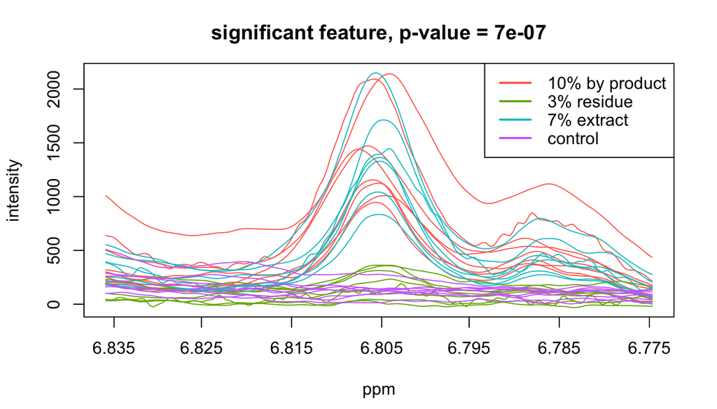

```r
peak_of_interest <- 1 # change this number to any of the peaks you want to see

drawSpecPPM(Y.spec = Spectra,
            X.ppm=ppm.onion,
            groupFactor = as.factor(onion.grouplabels),
            title = paste("significant feature, p-value =",
                          format(significant.features$p.values[peak_of_interest],
                                 scientific = TRUE, digits=2),
                          sep=" "),
            legend.extra.x = 1.1,
            legend.extra.y = 0.9,
            ROI = significant.features$index[peak_of_interest],
            roiWidth = 100,
            legendpos = "topright" )
```

When plotting all features it is clear that the peak_of_interest corresponding to index 19510 might be an artifact as the signals exhibit some strange background behaviour, and only this. Nonetheless we can sumbit these peaks to a database like [HMDB](http://www.hmdb.ca/) to identify the possible biomarker metabolites. As explained in the paper one cannot simply submit all the ppm values corresponding to these peaks to the database search, as results will be obfusciated by the amount of peaks (this is because of the Jaccard index that is used by HMDB). Therefor it is advised to perform a correlation analysis first to somewhat group the peaks in advance, note hoewever that this does not always work perfectly since peaks of different molecules can exhibit a correlation that can be larger than different peaks of the same molecule because of the way the wavelets quantify peaks. Nonetheless it works overall.

The other cluster of 2 cannot be assigned to a peak as at least one of these peaks is clearly a background signal (peak index 19510).

The peak with index 19752 is actually a small peak within the tail of the dimethyl sulfone peak. This is detected because in the peak detection we set **include_nearbyPeaks = TRUE**. Notice that these peaks are actually anti-correlated, this is because the wavelets are extremely good at ignoring the background, so good in fact that they detect the small bump in the tail of the large peak whereby this tail is the background. So actually this peak should be bigger but it is masked by the large tail. setting **include_nearbyPeaks = FALSE** will remove this peak but other important peaks might be missed than as wel.

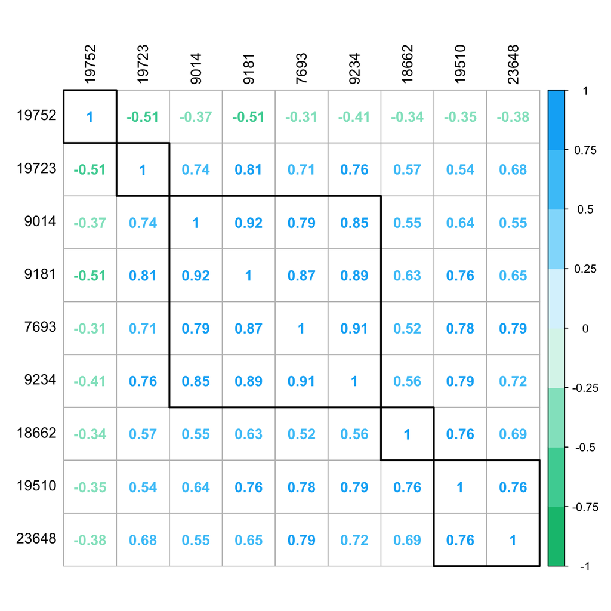

```r
library(stats)
library(corrplot)
significant.peakdata <- onion.Features.scaled[, p.all_bonf$p.values<=0.05]

corr.analysis <- cor(significant.peakdata)
corr.colours <- colorRampPalette(c("#00BF7D", "white", "#00B0F6"))
corrplot(corr.analysis,
         method="number",
         order="hclust",
         addrect = 5,
         tl.col = "black",
         col = corr.colours(8) )
```

## Conclusion

With only a few (easy) functions we where able to reproduce the results found by Winning et al., however the workflow above is clearly easier and faster than theirs (which was based in spectral binning) and yet resulted in more peaks to be used for identification.